# MonVote2027

Scraping, translating and de-Frenchifying 100 ballot statements

Author

Claude Code

Published

September 26, 2026

```r
library(tidyverse)
library(rvest)
library(jsonlite)
library(gt)

theme_set(theme_minimal(base_size = 12))
set.seed(1312)
```

## Source

[monvote2027.fr](https://monvote2027.fr/donnees) is a voting-advice quiz for the 2027 French presidential election: 100 statements, each with a context note, theme tags, and 23 candidates placed on a five-point scale.

- **No API.** Pages are server-rendered HTML; `/api`, `/api/questions`, `/data.json` and the like all 404. The data page loads no JSON — everything is in the markup.
- **Not on GitHub.** No `monvote2027` repo or org exists; the `monvote` hits are unrelated.
- **Licence is unnamed.** The *mentions légales* say the editorial content (questions, positions, texts) is “mis à disposition sous licence ouverte” — no licence is named. In France that phrase usually means Etalab Licence Ouverte 2.0 (attribution only), but that is an inference. **Ask them before anything ships in the public deck.** Candidate photos are explicitly excluded, and nothing here uses them.
- `robots.txt` allows everything except `/resultats` and `/partage`.

The per-candidate pages hold sources for every position. They are specific to this election and are deliberately left out.

## Snapshot

The site changes as candidates move, so the notebook reads a dated snapshot, not the live page. Delete the file (or change the date) to take a new one. Snapshots are gitignored; the tidy outputs below are what’s committed.

```r
snapshot <- "data/raw/monvote2027-donnees-2026-09-26.html"

if (!file.exists(snapshot)) {
  dir.create(dirname(snapshot), recursive = TRUE, showWarnings = FALSE)
  download.file("https://monvote2027.fr/donnees", snapshot, quiet = TRUE)
}

page <- read_html(snapshot)
```

## Parse

Each statement is a `.donnees-question`. The id and theme slugs sit in `data-qid` and `data-tags` (the visible tag chips are display copy). The context note is the `?` tooltip. The positions grid has five columns, one per point on the scale, each holding the candidate bubbles placed there.

```r
blocks <- html_elements(page, ".donnees-question")

questions_fr <- tibble(
  qid        = html_attr(blocks, "data-qid"),
  num        = parse_number(qid),
  text_fr    = map_chr(blocks, \(b) html_text2(html_element(b, ".donnees-q-text"))),
  context_fr = map_chr(blocks, \(b) html_text2(html_element(b, ".q-info-tooltip"))),
  tags_fr    = html_attr(blocks, "data-tags"),
  quick_quiz = map_lgl(blocks, \(b) length(html_elements(b, ".q-tag-rapide")) > 0)
)

# One row per candidate per statement. The column's dot class carries the score:
# pos-dot-2 = "tout à fait pour" (+2) … pos-dot--2 = "tout à fait contre" (−2).
positions <- map_dfr(blocks, \(b) {
  map_dfr(html_elements(b, ".pos-col"), \(col) {
    tibble(
      position = html_element(col, ".pos-dot") |>
        html_attr("class") |>
        str_extract("pos-dot-(-?\\d)", group = 1) |>
        as.integer(),
      cid = html_attr(html_elements(col, ".pos-cand-bubble"), "data-cid")
    )
  }) |>
    mutate(qid = html_attr(b, "data-qid"), .before = 1)
})

stopifnot(
  nrow(questions_fr) == 100,
  !anyDuplicated(questions_fr$qid),
  !anyNA(questions_fr$context_fr),
  sum(questions_fr$quick_quiz) == 20
)

candidates_per_q <- count(positions, qid)
n_candidates <- n_distinct(positions$cid)
gaps <- filter(candidates_per_q, n != n_candidates)

write_csv(questions_fr, "data/monvote2027-fr.csv")

tibble(
  statements = nrow(questions_fr),
  candidates = n_candidates,
  `statements missing a candidate` = nrow(gaps),
  `quick-quiz statements` = sum(questions_fr$quick_quiz)
) |>
  gt()
```

| statements | candidates | statements missing a candidate | quick-quiz statements |
| --- | --- | --- | --- |
| 100 | 23 | 0 | 20 |

## Themes

28 theme slugs; most statements carry two or three. They map onto the deck’s existing tag vocabulary where there is an obvious match (`immigration` → `migration`, `fiscal` → `tax`, `numerique` → `technology`, `laicite` → `religion`).

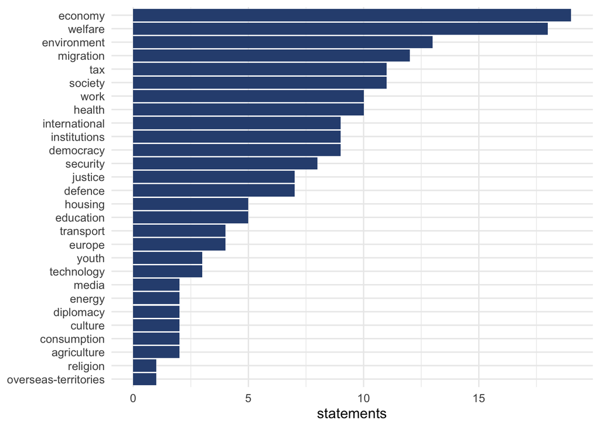

```r
tag_map <- c(
  immigration = "migration", securite = "security", justice = "justice",
  economie = "economy", fiscal = "tax", social = "welfare", travail = "work",
  sante = "health", international = "international", diplomatie = "diplomacy",
  europe = "europe", democratie = "democracy", institutions = "institutions",
  education = "education", energie = "energy", environnement = "environment",
  societe = "society", defense = "defence", agriculture = "agriculture",
  logement = "housing", numerique = "technology", laicite = "religion",
  culture = "culture", medias = "media", outremer = "overseas-territories",
  jeunesse = "youth", transport = "transport", consommation = "consumption"
)

tags_long <- questions_fr |>
  select(qid, tags_fr) |>
  separate_longer_delim(tags_fr, ",") |>
  mutate(tag = tag_map[tags_fr])

stopifnot(!anyNA(tags_long$tag))

tags_long |>
  count(tag, sort = TRUE) |>
  ggplot(aes(n, fct_reorder(tag, n))) +
  geom_col(fill = "#2f4f7f") +
  labs(x = "statements", y = NULL)
```

## Which statements split the field

This is the one thing the candidate positions are good for here. A statement every candidate agrees with makes a dead discussion card; one that splits the field down the middle is a live one. `for` and `against` count candidates on each side of neutral; `balance` is 1 when the two sides are equal and 0 when one side is empty.

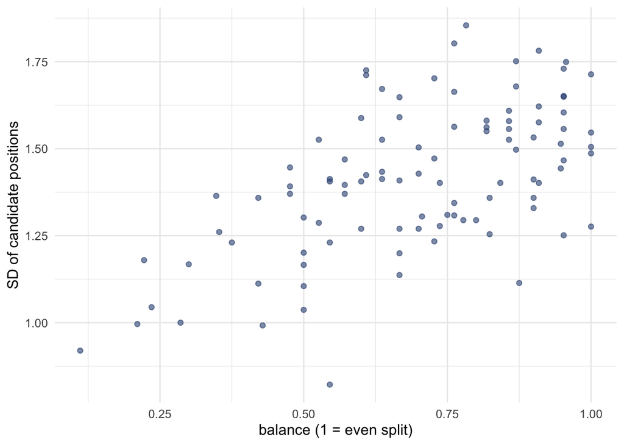

```r
split <- positions |>
  group_by(qid) |>
  summarise(
    `for`     = sum(position > 0),
    against   = sum(position < 0),
    neutral   = sum(position == 0),
    sd        = sd(position),
    .groups = "drop"
  ) |>
  mutate(balance = 1 - abs(`for` - against) / pmax(`for` + against, 1))

split |>
  ggplot(aes(balance, sd)) +
  geom_point(alpha = 0.6, colour = "#2f4f7f") +
  labs(x = "balance (1 = even split)", y = "SD of candidate positions")
```

## English, and how much of it travels

The translations live in `data/monvote2027-en.csv`, keyed by `qid` and edited by hand (the same pattern as `word-codes.csv`). Each statement gets a literal `text_en` and a faithful `context_en`, a `scope` code, and up to three rewrites for the deck:

- `text_generic`: the statement without its French specifics (below).
- `text_deck`: the flattest statements rewritten in the deck’s voice (see *The voice gap*).
- `context_generic`: the context note rewritten to stay true: what the idea is and the main case for and against. No countries, dates or figures, which would read oddly outside France and go out of date.

The scope codes:

- **universal**: works anywhere as written.
- **adaptable**: names a French institution, policy or “en France”, but there’s a plain equivalent (the SMIC is a minimum wage; article 49.3 is a government passing a law without a vote). `text_generic` holds the rewrite.
- **eu**: makes sense only for an EU member state.
- **france**: no useful equivalent (Parcoursup, the overseas territories, French troops in Africa, bullfighting).

```r
en <- read_csv("data/monvote2027-en.csv", show_col_types = FALSE)

stopifnot(
  setequal(en$qid, questions_fr$qid),
  en$scope %in% c("universal", "adaptable", "eu", "france"),
  # every statement that doesn't travel as written has a rewrite, or is marked france
  !anyNA(en$text_generic[en$scope == "adaptable"]),
  # everything that gets exported has a country-neutral context
  !anyNA(en$context_generic[en$scope != "france"])
)

statements <- questions_fr |>
  left_join(en, by = "qid") |>
  left_join(split, by = "qid") |>
  mutate(
    text = coalesce(text_deck, text_generic, text_en),
    scope = factor(scope, levels = c("universal", "adaptable", "eu", "france"))
  )

statements |>
  count(scope) |>
  mutate(share = n / sum(n)) |>
  gt() |>
  fmt_percent(share, decimals = 0)
```

| scope | n | share |
| --- | --- | --- |
| universal | 57 | 57% |
| adaptable | 35 | 35% |
| eu | 4 | 4% |
| france | 4 | 4% |

92 of the 100 work anywhere as written (57) or with a light rewrite (35); four more need an EU member state, and only four are genuinely French. The adaptable rewrites mostly strip “France”, swap a French acronym for the generic thing, or turn “France should…” into “My country should…”.

```r
statements |>
  filter(scope == "adaptable") |>
  select(qid, text_en, text_generic) |>
  slice_head(n = 12) |>
  gt() |>
  cols_label(text_en = "literal", text_generic = "generic")
```

| qid | literal | generic |
| --- | --- | --- |
| q1 | Legal immigration into France should be significantly reduced. | Legal immigration should be significantly reduced. |
| q5 | France should enforce ICC arrest warrants, even against the leaders of allied countries. | My country should enforce ICC arrest warrants, even against the leaders of allies. |
| q7 | Some proportional representation should be introduced in parliamentary elections. | Parliamentary seats should be allocated by proportional representation. |
| q8 | The state should hire massively in hospitals and state schools. | The state should hire massively in hospitals and schools. |
| q9 | The SMIC (minimum wage) should be raised significantly. | The minimum wage should be raised significantly. |
| q10 | Nuclear power should remain a pillar of French energy policy. | Nuclear power should be a pillar of energy policy. |
| q12 | France should leave NATO. | My country should leave NATO. |
| q13 | A citizens' initiative referendum (RIC) should be introduced. | Citizens should be able to force a national referendum by collecting signatures. |
| q15 | France should end its subsidies for fossil fuels. | Governments should end all subsidies for fossil fuels. |
| q17 | France should officially apologise for its colonial past. | Former colonial powers should officially apologise for their colonial past. |
| q19 | State medical aid (AME) for undocumented migrants should be abolished. | Free healthcare for undocumented migrants should be abolished. |
| q20 | France should increase its development aid to countries of the Global South. | Rich countries should increase their development aid to the Global South. |

## Shortlist

The statements that travel (universal or adaptable), ranked by how evenly they split the candidates. The top of this table is where to start picking cards — with the caveat that it measures what splits 23 *French* candidates, fringe ones weighted the same as frontrunners. That’s a decent proxy for a live card, not a prediction of what splits a table elsewhere.

```r
statements |>
  filter(scope %in% c("universal", "adaptable")) |>
  arrange(desc(balance), desc(sd)) |>
  select(qid, text, scope, `for`, against, neutral, balance) |>
  gt() |>
  fmt_number(balance, decimals = 2) |>
  opt_interactive(use_search = TRUE, page_size_default = 15)
```

| qid | text | scope | for | against | neutral | balance |
| --- | --- | --- | --- | --- | --- | --- |
| q23 | Foreign residents with legal status should get the right to vote in local elections. | universal | 10 | 10 | 3 | 1 |
| q32 | Prison is the wrong punishment for non-violent crime. | universal | 10 | 10 | 3 | 1 |
| q28 | My country should take in more asylum seekers. | adaptable | 10 | 10 | 3 | 1 |
| q78 | Conspicuous religious symbols should be banned for everyone in public services, staff and users alike. | universal | 11 | 11 | 1 | 1 |
| q86 | The voting age should be lowered to 16. | universal | 9 | 9 | 5 | 1 |
| q38 | Nobody should inherit a fortune without paying extra for it. | universal | 12 | 11 | 0 | 0.956521739130435 |
| q29 | Repeat offenders should face mandatory minimum sentences. | adaptable | 10 | 11 | 2 | 0.952380952380952 |
| q51 | Assisted dying should be legal. | adaptable | 11 | 10 | 2 | 0.952380952380952 |
| q22 | Foreigners without legal status should be systematically deported. | universal | 11 | 10 | 2 | 0.952380952380952 |
| q33 | An independent authority should be created to investigate police violence. | universal | 11 | 10 | 2 | 0.952380952380952 |

[output cut: 82 more lines]

## The voice gap

These are ballot statements, written to be answered on a five-point scale: flat, qualified, measurable. The claims deck is written to be argued about.

```r
# The MonVote claims are merged into claims.json now; compare against the rest.
claims <- fromJSON("../data/claims.json") |>
  filter(source != "Adapted from MonVote2027")

bind_rows(
  claims |> slice_sample(n = 5) |> transmute(deck = "claims.json", text),
  statements |> slice_sample(n = 5) |> transmute(deck = "MonVote2027", text)
) |>
  gt(groupname_col = "deck")
```

| text |
| --- |
| claims.json |
| Climate is the one fight that outranks every other fight. |
| First-generation immigrants can never be fully integrated within their new country. |
| A computer could run an economy better than a market can. |
| Although the electronic age makes official surveillance easier, only wrongdoers need to be worried. |
| Gays and lesbians are just as healthy and moral as anybody else. |
| MonVote2027 |
| National defence spending should reach 3% of GDP. |
| My country should step up its military support for Ukraine. |
| Assisted reproduction should be fully reimbursed and access to it widened (age, medical criteria). |
| The standard working week is too short. |
| The sale of new petrol and diesel cars should be banned by 2035. |

A literal translation reads noticeably flatter than the rest of the deck. The flattest 28 have a `text_deck` rewrite that keeps the proposition but gives a player something to push back on; the rest go in as translated.

```r
statements |>
  filter(!is.na(text_deck)) |>
  transmute(qid, before = coalesce(text_generic, text_en), text_deck) |>
  gt() |>
  cols_label(text_deck = "deck voice")
```

| qid | before | deck voice |
| --- | --- | --- |
| q2 | Sentences for violent crimes and offences should be made harsher. | Violent criminals get off too lightly. |
| q3 | Taxes on the very largest fortunes should be raised. | The very rich should pay far more tax. |
| q7 | Parliamentary seats should be allocated by proportional representation. | Every vote should count the same: parliament should be elected by proportional representation. |
| q8 | The state should hire massively in hospitals and schools. | Hospitals and schools need an army of new public hires, whatever it costs. |
| q11 | Some public services should be opened up to private management. | Private companies would run some public services better than the state does. |
| q18 | The state should launch a major public investment plan, even at the cost of a larger deficit. | Borrow big and build. The deficit can wait. |
| q26 | Immigrants coming to work should be given priority over others for admission. | Let workers in first. Everyone else can wait. |
| q31 | Funded (capitalised) pensions should be developed alongside pay-as-you-go pensions. | Part of everyone's pension should be invested in the stock market. |
| q32 | Alternatives to prison (electronic tags, community service, suspended sentences) should be preferred for non-violent offences. | Prison is the wrong punishment for non-violent crime. |
| q34 | A seat in parliament should be incompatible with any other paid professional activity. | Being an MP should be a full-time job, with no side income. |
| q37 | The state should guarantee farmers minimum prices that give them a decent income. | Farmers should be guaranteed a price they can live on, whatever the market says. |
| q38 | An exceptional levy should be introduced on inheritances above €2 million. | Nobody should inherit a fortune without paying extra for it. |
| q39 | Employer social security contributions should be cut. | Employers pay too much to hire people. |
| q40 | Companies that received public aid should not be allowed to relocate abroad for 10 years. | Take public money, and you don't get to move the jobs abroad. |
| q41 | Strategic sectors (energy, transport) should be nationalised. | Energy and transport should belong to the state. |
| q46 | VAT on essential goods should be abolished. | Food and soap shouldn't be taxed at all. |
| q47 | The legal working week should be longer. | The standard working week is too short. |
| q53 | A progressive carbon tax should be introduced on plane tickets. | The more you fly, the more tax you should pay per ticket. |
| q54 | The governance of large companies should be shared equally between shareholder and employee representatives. | Workers should have as many seats on the board as shareholders. |
| q56 | Procedures for economic redundancies should be simplified. | It should be easier to lay people off. |
| q64 | A windfall tax should be introduced on the excess profits of oil companies. | Oil companies' crisis profits should be taxed away. |
| q76 | The state should be able to requisition empty homes to tackle the housing crisis. | The state should be able to seize empty homes to house people. |
| q77 | Farm subsidies should be conditional on strict environmental standards. | No farm subsidies without strict environmental rules. |
| q82 | A legal maximum income should be introduced. | Nobody should be allowed to earn more than a legal maximum. |
| q83 | The law should limit concentrated ownership of news media. | No single owner should control too much of the news. |
| q84 | School catchment areas should be abolished so families can freely choose their school. | Parents should be free to pick any school, not the one they're assigned. |
| q90 | Medical deserts should be tackled by creating public health centres with salaried doctors. | Doctor shortages should be fixed with public clinics and salaried doctors. |
| q100 | Building in protected areas should be made easier to meet housing needs. | Protected land should be opened up for housing. |

## Export

`data/monvote2027-claims.json` is shaped like `data/claims.json`, plus two fields. The 96 claims in it were merged into `data/claims.json` as `c152`–`c247`, without `origin`. Re-rendering rewrites this file, never `data/claims.json`: edits to merged cards happen in `data/claims.json`.

- `id`: the next free `c` numbers, in MonVote order. Card numbers come from the digits in the id (`claimNumber`), so an `mv001`-style id would print as #1 and collide with `c001`.
- `context`: the country-neutral context note. **New field**; the claims deck shows it behind a “What’s this about?” button.
- `origin`: the MonVote id, the French text and the scope, for traceability.
- `axis` is the first tag, because `Claim.axis` is a required string.

Every statement except the four France-only ones is exported; the eu ones are flagged in `origin.scope`.

```r
exported <- statements |>
  filter(scope != "france") |>
  left_join(
    tags_long |> summarise(tags = list(unname(tag)), .by = qid),
    by = "qid"
  ) |>
  transmute(
    id = sprintf("c%03d", 151 + row_number()),
    text,
    followUp = NA_character_,
    source = "Adapted from MonVote2027",
    axis = map_chr(tags, 1),
    # I() keeps a one-tag list an array; auto_unbox would write it as a string.
    tags = map(tags, I),
    context = context_generic,
    origin = pmap(
      list(qid, text_fr, as.character(scope)),
      \(qid, text_fr, scope) list(
        site = "monvote2027.fr", qid = qid, text_fr = text_fr, scope = scope
      )
    )
  )

write_json(
  exported, "data/monvote2027-claims.json",
  auto_unbox = TRUE, pretty = TRUE, na = "null"
)

write_csv(
  statements |> select(qid, scope, text, `for`, against, neutral, balance, sd),
  "data/monvote2027-split.csv"
)

nrow(exported)
```

```
[1] 96
```